# Producto 3 — Sostenibilidad demográfica y fiscal

Riesgos Macrofiscales del Cambio Demográfico en ALC · CAF · CW29884

Héctor J. Villarreal Páez · Juan Pablo López Reynosa

05 de August de 2026

> **Propósito de este archivo.** Genera las figuras y tablas de la sección “Sostenibilidad demográfica y fiscal” del Producto 3. Las figuras se exportan a `graficas/` y las tablas dependientes de estimación a `tablas/` en formato `.tex` (booktabs), listas para `\input{}` desde Overleaf.

```r
library(readxl)
library(tidyverse)
library(forecast)
library(tseries)

# Ajustar a la carpeta con los archivos brutos:
#   WEO_Gobierno_balance.xlsx · IMF_Pensiones_salud.xlsx · demografia_LIMPIA.xlsx
# setwd("C:/ruta/a/tu/carpeta")

dir.create("graficas", showWarnings = FALSE)
dir.create("tablas",   showWarnings = FALSE)

# --- Codificación ---------------------------------------------------------
# Este archivo debe estar guardado en UTF-8. Si los acentos del propio código
# se ven mal en el editor, en RStudio: File > Reopen with Encoding > UTF-8
# (y luego File > Save with Encoding > UTF-8 para dejarlo fijo).
# Los .csv se exportan con readr::write_excel_csv, que escribe UTF-8 con BOM
# para que Excel en Windows los abra correctamente.
cat("Locale:", Sys.getlocale("LC_CTYPE"), "\n")
```

```
## Locale: English_United States.utf8
```

```r
cat("Codificación nativa:", l10n_info()$codeset, "\n")
```

```
## Codificación nativa:
```

```r
# Paleta institucional (sin colores pastel por defecto de ggplot2)
paleta_paises <- c(
  "Brasil"     = "#1B3A5C",  # azul marino
  "Chile"      = "#8C1D40",  # granate
  "Colombia"   = "#3E7C8C",  # azul petróleo
  "Costa Rica" = "#B08D57",  # bronce
  "México"     = "#4C6445",  # verde oscuro
  "Panamá"     = "#5C5C5C"   # gris carbón
)
color_hist <- "#1B3A5C"; color_fc <- "#8C1D40"

theme_caf <- function(base_size = 11) {
  theme_minimal(base_size = base_size) +
    theme(
      plot.title       = element_text(face = "bold", size = rel(1.02), color = "#1B3A5C"),
      plot.subtitle    = element_text(size = rel(0.82), color = "grey35"),
      plot.caption     = element_text(size = rel(0.68), color = "grey45", hjust = 0),
      strip.background = element_rect(fill = "#1B3A5C", color = NA),
      strip.text       = element_text(color = "white", face = "bold", size = rel(0.78)),
      panel.grid.minor = element_blank(),
      panel.grid.major = element_line(color = "grey88", linewidth = 0.3),
      panel.background = element_rect(fill = "white", color = NA),
      plot.background  = element_rect(fill = "white", color = NA),
      legend.position  = "bottom",
      legend.title     = element_text(face = "bold", size = rel(0.82)),
      legend.text      = element_text(size = rel(0.78)),
      axis.title       = element_text(size = rel(0.82), color = "grey20"),
      axis.text        = element_text(color = "grey30")
    )
}

# Exportador de tablas a LaTeX (booktabs, sin entorno table: se envuelve en el .tex)
exportar_tex <- function(df, archivo, alinear = NULL) {
  if (is.null(alinear)) alinear <- c("l", rep("r", ncol(df) - 1))
  cat(
    knitr::kable(df, format = "latex", booktabs = TRUE, linesep = "",
                 align = alinear, escape = TRUE),
    file = file.path("tablas", archivo)
  )
  invisible(df)
}
```

# 1 Demografía: proyecciones de UN World Population Prospects

Las series demográficas provienen de **UN World Population Prospects 2024, revisión mediana**. No se ajusta modelo econométrico propio sobre ellas: la División de Población de Naciones Unidas ya produce la proyección de largo plazo bajo supuestos explícitos de fecundidad, mortalidad y migración. Aquí se reproducen y se usan como marco de referencia demográfico del análisis fiscal.

```r
demog_tfr <- read_excel("limpio/demografia_LIMPIA.xlsx", sheet = "tfg")
demog_dep <- read_excel("limpio/demografia_LIMPIA.xlsx", sheet = "dependencia")
resumen_demog <- read_excel("limpio/demografia_LIMPIA.xlsx", sheet = "resumen_tab_demog")

anio_corte_demog <- 2023   # WPP: estimación hasta 2023; proyección mediana desde 2024

tfr <- demog_tfr %>%
  transmute(pais, anio = as.integer(anio),
            indicador = "Tasa global de fecundidad (hijos por mujer)",
            valor = as.numeric(valor))

dep_senil <- demog_dep %>%
  filter(indicador == "Razón de dependencia senil (65+/15-64)") %>%
  transmute(pais, anio = as.integer(anio),
            indicador = "Razón de dependencia senil (%)",
            valor = as.numeric(valor) * 100)

df_demog <- bind_rows(tfr, dep_senil) %>%
  mutate(
    indicador = factor(indicador, levels = c(
      "Tasa global de fecundidad (hijos por mujer)",
      "Razón de dependencia senil (%)")),
    periodo = if_else(anio <= anio_corte_demog, "Estimación", "Proyección (mediana)")
  )
```

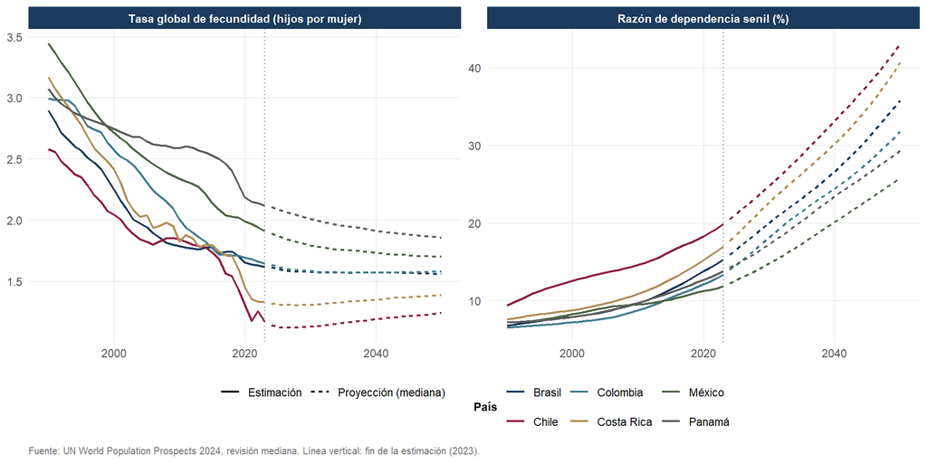

```r
g_demog <- ggplot(df_demog, aes(anio, valor, color = pais, linetype = periodo)) +
  geom_line(linewidth = 0.8) +
  geom_vline(xintercept = anio_corte_demog, linetype = "dotted", color = "grey50") +
  facet_wrap(~ indicador, scales = "free_y", nrow = 1) +
  scale_color_manual(values = paleta_paises) +
  scale_linetype_manual(values = c("Estimación" = "solid", "Proyección (mediana)" = "22")) +
  labs(x = NULL, y = NULL, color = "País", linetype = NULL,
       caption = "Fuente: UN World Population Prospects 2024, revisión mediana. Línea vertical: fin de la estimación (2023).") +
  theme_caf()
print(g_demog)
```

```r
ggsave("graficas/fig_demografia.png", g_demog, width = 10, height = 5, dpi = 300)
```

```r
tab_demog <- resumen_demog %>%
  transmute(
    País = pais,
    `TFR (2024)`        = round(TFR_2024, 2),
    `RD senil 2025 (\\%)` = round(RD_senil_2025 * 100, 1),
    `RD senil 2050 (\\%)` = round(RD_senil_2050 * 100, 1),
    `Factor 2025--2050`   = round(veces_duplica_RD, 2)
  ) %>%
  arrange(desc(`RD senil 2050 (\\%)`))

knitr::kable(tab_demog, caption = "Indicadores demográficos, seis países (UN WPP 2024)")
```

Indicadores demográficos, seis países (UN WPP 2024)

| País | TFR (2024) | RD senil 2025 (%) | RD senil 2050 (%) | Factor 2025–2050 |
| --- | --- | --- | --- | --- |
| Chile | 1.14 | 21.2 | 43.1 | 2.04 |
| Costa Rica | 1.32 | 18.5 | 40.7 | 2.20 |
| Brasil | 1.61 | 16.6 | 35.8 | 2.16 |
| Colombia | 1.63 | 14.6 | 31.7 | 2.17 |
| Panamá | 2.11 | 14.7 | 29.4 | 2.00 |
| México | 1.89 | 12.6 | 25.9 | 2.05 |

```r
exportar_tex(tab_demog, "tab_demografia.tex")
```

# 2 Fiscal: análisis descriptivo

Cinco indicadores, todos como porcentaje del PIB. Ingresos, balance primario y deuda neta provienen del **FMI, World Economic Outlook (abril 2025)**; el gasto en salud y en pensiones, de la base **CEPAL/FMI-GFS de gasto público por función**, con cobertura de gobierno central.

```r
weo_raw <- read_excel("WEO_Gobierno_balance.xlsx",
                      sheet = "WEO_Gobierno_balance", na = c("n/a", "--", ""))
imf_raw <- read_excel("IMF_Pensiones_salud.xlsx", sheet = "datos")

anios_weo <- as.character(2000:2024)

# --- WEO: ingresos, balance primario, deuda neta y gasto total ---
weo_long <- weo_raw %>%
  filter(!is.na(ISO)) %>%
  filter(`WEO Subject Code` %in% c("GGR_NGDP", "GGXONLB_NGDP",
                                   "GGXWDN_NGDP", "GGX_NGDP")) %>%
  select(ISO, code = `WEO Subject Code`, all_of(anios_weo)) %>%
  mutate(across(all_of(anios_weo), as.character)) %>%
  pivot_longer(all_of(anios_weo), names_to = "anio", values_to = "valor") %>%
  mutate(anio = as.integer(anio), valor = as.numeric(valor),
         pais = recode(ISO, BRA = "Brasil", CHL = "Chile", COL = "Colombia",
                       CRI = "Costa Rica", MEX = "México", PAN = "Panamá")) %>%
  filter(!is.na(valor))

weo <- weo_long %>%
  filter(code != "GGX_NGDP") %>%
  mutate(indicador = recode(code,
    GGR_NGDP     = "Ingresos del gobierno general",
    GGXONLB_NGDP = "Balance primario",
    GGXWDN_NGDP  = "Deuda neta del gobierno general")) %>%
  select(pais, anio, indicador, valor)

gasto_total <- weo_long %>%
  filter(code == "GGX_NGDP") %>%
  select(pais, anio, gasto_total = valor)

# --- Salud y pensiones (gobierno central) ---
imf <- imf_raw %>%
  select(pais = `País__ESTANDAR`, funcion = `Gasto público por función`,
         anio = `Años__ESTANDAR`, valor = value) %>%
  mutate(anio = as.integer(anio), valor = as.numeric(valor))

salud <- imf %>% filter(funcion == "Salud") %>%
  mutate(indicador = "Gasto público en salud") %>%
  select(pais, anio, indicador, valor)

imf_wide <- imf %>% filter(funcion != "Salud") %>%
  pivot_wider(names_from = funcion, values_from = valor) %>%
  rename(vejez = `Edad avanzada`, enfermedad = `Enfermedad e incapacidad`)

# Regla de agregación: se suma "Enfermedad e incapacidad" a "Edad avanzada"
# sólo si su cobertura alcanza el 70% de los años con dato de vejez; en caso
# contrario la serie es sólo vejez (cota inferior). Evita saltos de definición
# a mitad de muestra.
regla_pensiones <- imf_wide %>%
  group_by(pais) %>%
  summarise(n_vejez = sum(!is.na(vejez)), n_enf = sum(!is.na(enfermedad)),
            cobertura = round(n_enf / n_vejez, 2),
            incluye_enf = cobertura >= 0.7, .groups = "drop")

pensiones <- imf_wide %>%
  left_join(select(regla_pensiones, pais, incluye_enf), by = "pais") %>%
  mutate(valor = if_else(incluye_enf, vejez + enfermedad, vejez)) %>%
  filter(!is.na(valor)) %>%
  mutate(indicador = "Gasto público en pensiones") %>%
  select(pais, anio, indicador, valor)

niveles_ind <- c("Ingresos del gobierno general", "Balance primario",
                 "Deuda neta del gobierno general",
                 "Gasto público en salud", "Gasto público en pensiones")

df_fiscal <- bind_rows(weo, salud, pensiones) %>%
  mutate(indicador = factor(indicador, levels = niveles_ind)) %>%
  arrange(indicador, pais, anio)

# Conservar el tramo contiguo más reciente (requisito para declarar ts sin huecos)
tramo_contiguo <- function(d) {
  d <- arrange(d, anio)
  g <- cumsum(c(0, diff(d$anio) != 1))
  filter(mutate(d, g = g), g == max(g)) %>% select(-g)
}
df_fiscal <- df_fiscal %>% group_by(indicador, pais) %>%
  group_modify(~ tramo_contiguo(.x)) %>% ungroup()

knitr::kable(regla_pensiones,
             caption = "Regla de agregación de la serie de pensiones por país")
```

Regla de agregación de la serie de pensiones por país

| pais | n_vejez | n_enf | cobertura | incluye_enf |
| --- | --- | --- | --- | --- |
| Brasil | 26 | 21 | 0.81 | TRUE |
| Chile | 31 | 31 | 1.00 | TRUE |
| Colombia | 20 | 14 | 0.70 | TRUE |
| Costa Rica | 15 | 0 | 0.00 | FALSE |
| México | 22 | 1 | 0.05 | FALSE |
| Panamá | 14 | 8 | 0.57 | FALSE |

## 2.1 Una figura por indicador

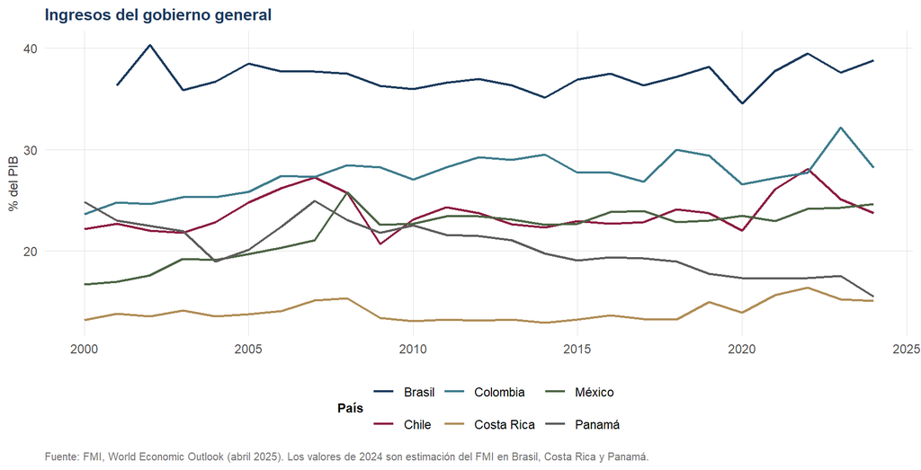

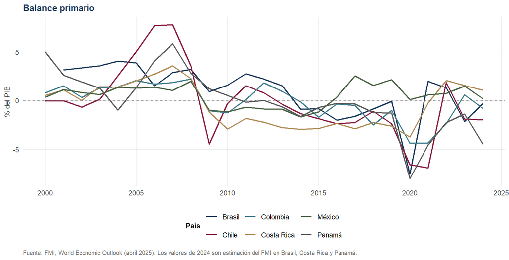

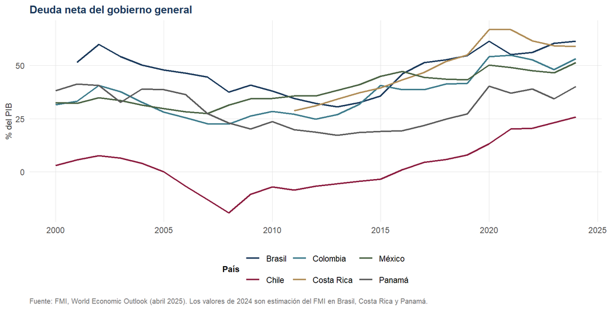

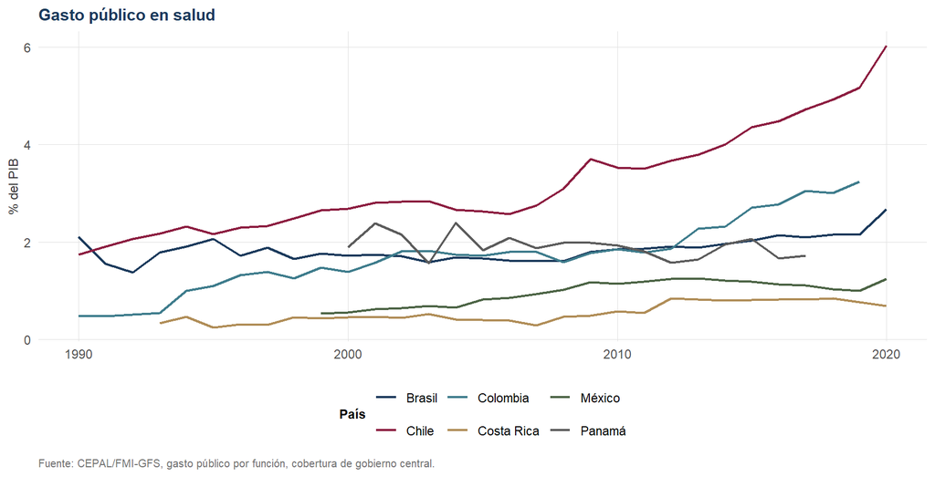

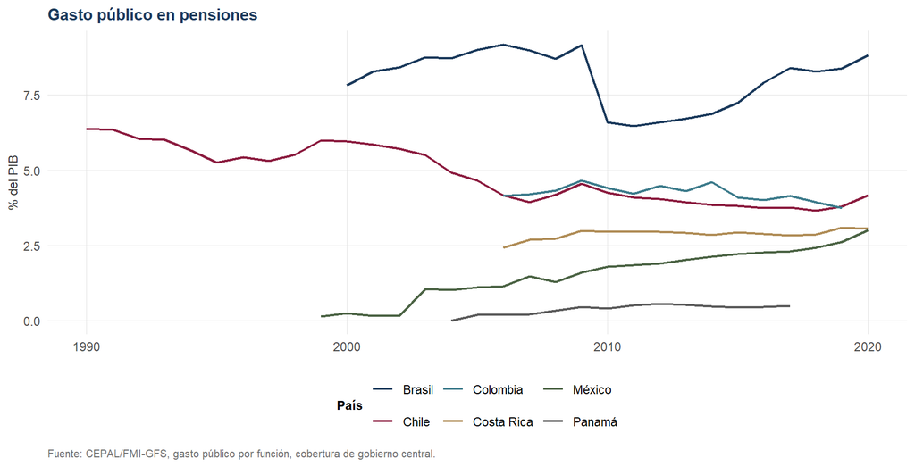

```r
archivos_fig <- c(
  "Ingresos del gobierno general"     = "fig_ingresos",
  "Balance primario"                  = "fig_balance",
  "Deuda neta del gobierno general"   = "fig_deuda",
  "Gasto público en salud"            = "fig_salud",
  "Gasto público en pensiones"        = "fig_pensiones"
)

fuente_weo <- "Fuente: FMI, World Economic Outlook (abril 2025). Los valores de 2024 son estimación del FMI en Brasil, Costa Rica y Panamá."
fuente_gfs <- "Fuente: CEPAL/FMI-GFS, gasto público por función, cobertura de gobierno central."

for (ind in levels(df_fiscal$indicador)) {
  d <- filter(df_fiscal, indicador == ind)
  es_weo <- ind %in% c("Ingresos del gobierno general", "Balance primario",
                       "Deuda neta del gobierno general")

  g <- ggplot(d, aes(anio, valor, color = pais)) +
    geom_line(linewidth = 0.85) +
    scale_color_manual(values = paleta_paises) +
    labs(title = ind, x = NULL, y = "% del PIB", color = "País",
         caption = if (es_weo) fuente_weo else fuente_gfs) +
    theme_caf()

  # El balance primario cruza el cero: se marca la referencia
  if (ind == "Balance primario") {
    g <- g + geom_hline(yintercept = 0, linetype = "dashed",
                        color = "grey45", linewidth = 0.4)
  }

  print(g)
  ggsave(paste0("graficas/", archivos_fig[[ind]], ".png"), g,
         width = 9, height = 4.6, dpi = 300)
}
```

## 2.2 Último dato disponible y variación anual

```r
# Último dato y variación (diferencia en p.p.) por serie
tab_ultimo <- df_fiscal %>%
  group_by(indicador, pais) %>%
  arrange(anio) %>%
  slice_tail(n = 2) %>%
  summarise(anio_t = last(anio), valor_t = last(valor),
            valor_t1 = first(valor), .groups = "drop") %>%
  mutate(delta = valor_t - valor_t1)

# --- Tabla A: agregados WEO (los tres terminan en 2024) ---
tab_weo <- tab_ultimo %>%
  filter(indicador %in% c("Ingresos del gobierno general", "Balance primario",
                          "Deuda neta del gobierno general")) %>%
  mutate(ind_corto = recode(as.character(indicador),
    "Ingresos del gobierno general"   = "Ingresos",
    "Balance primario"                = "Balance",
    "Deuda neta del gobierno general" = "Deuda")) %>%
  select(pais, ind_corto, valor_t, delta) %>%
  pivot_wider(names_from = ind_corto, values_from = c(valor_t, delta)) %>%
  transmute(País = pais,
            Ingresos    = round(valor_t_Ingresos, 1),
            `$\\Delta$ Ing.`   = sprintf("%+.1f", delta_Ingresos),
            Balance     = round(valor_t_Balance, 1),
            `$\\Delta$ Bal.`   = sprintf("%+.1f", delta_Balance),
            Deuda       = round(valor_t_Deuda, 1),
            `$\\Delta$ Deuda`  = sprintf("%+.1f", delta_Deuda)) %>%
  arrange(País)

knitr::kable(tab_weo,
             caption = "Agregados fiscales en 2024 y variación respecto a 2023 (% del PIB; variación en p.p.)")
```

Agregados fiscales en 2024 y variación respecto a 2023 (% del PIB; variación en p.p.)

| País | Ingresos | $\Delta$ Ing. | Balance | $\Delta$ Bal. | Deuda | $\Delta$ Deuda |
| --- | --- | --- | --- | --- | --- | --- |
| Brasil | 38.8 | +1.2 | -0.3 | +1.8 | 61.5 | +1.1 |
| Chile | 23.7 | -1.4 | -2.0 | -0.1 | 25.8 | +2.6 |
| Colombia | 28.2 | -4.0 | -0.8 | -1.4 | 53.2 | +5.1 |
| Costa Rica | 15.1 | -0.2 | 1.1 | -0.5 | 58.9 | -0.3 |
| México | 24.6 | +0.4 | 0.2 | -1.3 | 51.4 | +4.7 |
| Panamá | 15.5 | -2.0 | -4.5 | -3.1 | 40.2 | +5.8 |

```r
exportar_tex(tab_weo, "tab_ultimo_weo.tex")

# --- Tabla B: gasto funcional (año de corte distinto por país) ---
tab_gfs <- tab_ultimo %>%
  filter(indicador %in% c("Gasto público en salud", "Gasto público en pensiones")) %>%
  mutate(ind_corto = recode(as.character(indicador),
    "Gasto público en salud"     = "Salud",
    "Gasto público en pensiones" = "Pensiones")) %>%
  select(pais, ind_corto, anio_t, valor_t, delta) %>%
  pivot_wider(names_from = ind_corto, values_from = c(anio_t, valor_t, delta))

# Verificación: la columna "Año" asume que salud y pensiones terminan el mismo año
if (any(tab_gfs$anio_t_Salud != tab_gfs$anio_t_Pensiones)) {
  warning("Salud y pensiones tienen años de corte distintos en algún país: revisar tabla.")
}

tab_gfs <- tab_gfs %>%
  transmute(País = pais,
            Año = anio_t_Salud,
            Salud       = round(valor_t_Salud, 2),
            `$\\Delta$ Salud` = sprintf("%+.2f", delta_Salud),
            Pensiones   = round(valor_t_Pensiones, 2),
            `$\\Delta$ Pens.` = sprintf("%+.2f", delta_Pensiones)) %>%
  arrange(País)

knitr::kable(tab_gfs,
             caption = "Gasto en salud y pensiones: último año disponible y variación respecto al año previo")
```

Gasto en salud y pensiones: último año disponible y variación respecto al año previo

| País | Año | Salud | $\Delta$ Salud | Pensiones | $\Delta$ Pens. |
| --- | --- | --- | --- | --- | --- |
| Brasil | 2020 | 2.67 | +0.52 | 8.83 | +0.45 |
| Chile | 2020 | 6.03 | +0.87 | 4.17 | +0.36 |
| Colombia | 2019 | 3.24 | +0.24 | 3.75 | -0.19 |
| Costa Rica | 2020 | 0.69 | -0.08 | 3.06 | -0.03 |
| México | 2020 | 1.24 | +0.24 | 3.01 | +0.39 |
| Panamá | 2017 | 1.72 | +0.06 | 0.50 | +0.03 |

```r
exportar_tex(tab_gfs, "tab_ultimo_gfs.tex")
```

La variación se calcula como **diferencia** entre el último año disponible y el inmediato anterior, no como tasa de crecimiento: al estar las series expresadas ya en porcentaje del PIB, la métrica interpretable es el cambio en puntos porcentuales.

## 2.3 Importancia relativa de pensiones y salud en el gasto público

```r
gasto_funcional <- bind_rows(salud, pensiones) %>%
  pivot_wider(names_from = indicador, values_from = valor) %>%
  rename(salud = `Gasto público en salud`,
         pensiones = `Gasto público en pensiones`) %>%
  filter(!is.na(salud), !is.na(pensiones)) %>%
  inner_join(gasto_total, by = c("pais", "anio")) %>%
  mutate(
    suma_funcional = salud + pensiones,
    part_salud     = 100 * salud     / gasto_total,
    part_pensiones = 100 * pensiones / gasto_total,
    part_total     = 100 * suma_funcional / gasto_total
  )

# Último año con dato simultáneo de las tres fuentes, por país
comp_ultimo <- gasto_funcional %>%
  group_by(pais) %>% slice_max(anio, n = 1, with_ties = FALSE) %>% ungroup()

tab_composicion <- comp_ultimo %>%
  transmute(País = pais, Año = anio,
            `Salud (\\% PIB)`      = round(salud, 1),
            `Pensiones (\\% PIB)`  = round(pensiones, 1),
            `Gasto total (\\% PIB)` = round(gasto_total, 1),
            `Salud (\\% del gasto)`     = round(part_salud, 1),
            `Pensiones (\\% del gasto)` = round(part_pensiones, 1),
            `Suma (\\% del gasto)`      = round(part_total, 1)) %>%
  arrange(desc(`Suma (\\% del gasto)`))

knitr::kable(tab_composicion,
             caption = "Peso de salud y pensiones en el gasto público total, último año con dato simultáneo")
```

Peso de salud y pensiones en el gasto público total, último año con dato simultáneo

| País | Año | Salud (% PIB) | Pensiones (% PIB) | Gasto total (% PIB) | Salud (% del gasto) | Pensiones (% del gasto) | Suma (% del gasto) |
| --- | --- | --- | --- | --- | --- | --- | --- |
| Chile | 2020 | 6.0 | 4.2 | 29.1 | 20.7 | 14.3 | 35.1 |
| Brasil | 2020 | 2.7 | 8.8 | 46.2 | 5.8 | 19.1 | 24.9 |
| Colombia | 2019 | 3.2 | 3.7 | 32.9 | 9.9 | 11.4 | 21.3 |
| Costa Rica | 2020 | 0.7 | 3.1 | 22.3 | 3.1 | 13.7 | 16.8 |
| México | 2020 | 1.2 | 3.0 | 27.8 | 4.5 | 10.8 | 15.3 |
| Panamá | 2017 | 1.7 | 0.5 | 21.2 | 8.1 | 2.4 | 10.5 |

```r
exportar_tex(tab_composicion, "tab_composicion_gasto.tex")
```

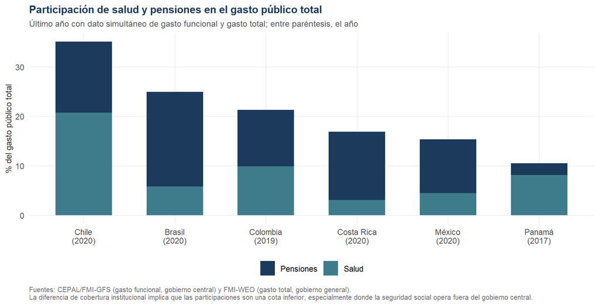

```r
d_comp <- comp_ultimo %>%
  select(pais, anio, Salud = part_salud, Pensiones = part_pensiones) %>%
  pivot_longer(c(Salud, Pensiones), names_to = "funcion", values_to = "participacion") %>%
  mutate(pais_lab = paste0(pais, "\n(", anio, ")"))

orden_pais <- comp_ultimo %>% arrange(desc(part_total)) %>%
  mutate(pais_lab = paste0(pais, "\n(", anio, ")")) %>% pull(pais_lab)
d_comp$pais_lab <- factor(d_comp$pais_lab, levels = orden_pais)

g_comp <- ggplot(d_comp, aes(pais_lab, participacion, fill = funcion)) +
  geom_col(width = 0.62) +
  scale_fill_manual(values = c("Salud" = "#3E7C8C", "Pensiones" = "#1B3A5C")) +
  labs(title = "Participación de salud y pensiones en el gasto público total",
       subtitle = "Último año con dato simultáneo de gasto funcional y gasto total; entre paréntesis, el año",
       x = NULL, y = "% del gasto público total", fill = NULL,
       caption = paste("Fuentes: CEPAL/FMI-GFS (gasto funcional, gobierno central) y FMI-WEO (gasto total, gobierno general).",
                       "\nLa diferencia de cobertura institucional implica que las participaciones son una cota inferior, especialmente donde la seguridad social opera fuera del gobierno central.")) +
  theme_caf()
print(g_comp)
```

```r
ggsave("graficas/fig_composicion_gasto.png", g_comp, width = 9, height = 4.6, dpi = 300)
```

# 3 Proyecciones fiscales

## 3.1 Pipeline

```r
claves <- df_fiscal %>% distinct(indicador, pais) %>% arrange(indicador, pais)
series_list <- vector("list", nrow(claves))
names(series_list) <- paste(claves$indicador, claves$pais, sep = " — ")
for (i in seq_len(nrow(claves))) {
  d <- df_fiscal %>%
    filter(indicador == claves$indicador[i], pais == claves$pais[i]) %>% arrange(anio)
  series_list[[i]] <- ts(d$valor, start = min(d$anio), frequency = 1)
}
cat("Series construidas:", nrow(claves), "\n")
```

```
## Series construidas: 30
```

```r
library(strucchange)
```

```r
tab_integracion <- map_dfr(seq_len(nrow(claves)), function(i) {
  y <- series_list[[i]]
  tibble(
    Indicador = as.character(claves$indicador[i]),
    pais      = claves$pais[i],
    n         = length(y),
    ADF_p     = tryCatch(round(suppressWarnings(adf.test(y)$p.value), 3),  error = function(e) NA),
    KPSS_p    = tryCatch(round(suppressWarnings(kpss.test(y)$p.value), 3), error = function(e) NA),
    d         = tryCatch(ndiffs(y), error = function(e) NA_integer_)
  )
})

resumen_d <- tab_integracion %>%
  count(Indicador, d) %>%
  pivot_wider(names_from = d, values_from = n, values_fill = 0,
              names_prefix = "d = ")

knitr::kable(resumen_d,
             caption = "Orden de integración sugerido (ndiffs), número de países por indicador")
```

Orden de integración sugerido (ndiffs), número de países por indicador

| Indicador | d = 0 | d = 1 | d = 2 |
| --- | --- | --- | --- |
| Balance primario | 2 | 4 | 0 |
| Deuda neta del gobierno general | 2 | 4 | 0 |
| Gasto público en pensiones | 1 | 5 | 0 |
| Gasto público en salud | 1 | 4 | 1 |
| Ingresos del gobierno general | 3 | 3 | 0 |

```r
exportar_tex(resumen_d, "tab_integracion.tex")

knitr::kable(tab_integracion, caption = "Detalle por serie: pruebas de raíz unitaria y diferencias sugeridas")
```

Detalle por serie: pruebas de raíz unitaria y diferencias sugeridas

| Indicador | pais | n | ADF_p | KPSS_p | d |
| --- | --- | --- | --- | --- | --- |
| Ingresos del gobierno general | Brasil | 24 | 0.964 | 0.100 | 0 |
| Ingresos del gobierno general | Chile | 25 | 0.523 | 0.100 | 0 |
| Ingresos del gobierno general | Colombia | 25 | 0.349 | 0.018 | 1 |
| Ingresos del gobierno general | Costa Rica | 25 | 0.790 | 0.100 | 0 |
| Ingresos del gobierno general | México | 25 | 0.513 | 0.013 | 1 |
| Ingresos del gobierno general | Panamá | 25 | 0.568 | 0.010 | 1 |
| Balance primario | Brasil | 24 | 0.582 | 0.011 | 1 |
| Balance primario | Chile | 25 | 0.166 | 0.056 | 1 |
| Balance primario | Colombia | 25 | 0.040 | 0.022 | 1 |
| Balance primario | Costa Rica | 25 | 0.885 | 0.100 | 0 |
| Balance primario | México | 25 | 0.476 | 0.100 | 0 |
| Balance primario | Panamá | 25 | 0.063 | 0.010 | 1 |
| Deuda neta del gobierno general | Brasil | 24 | 0.696 | 0.100 | 0 |
| Deuda neta del gobierno general | Chile | 25 | 0.713 | 0.057 | 1 |
| Deuda neta del gobierno general | Colombia | 25 | 0.413 | 0.024 | 1 |
| Deuda neta del gobierno general | Costa Rica | 14 | 0.642 | 0.037 | 1 |
| Deuda neta del gobierno general | México | 25 | 0.146 | 0.010 | 1 |
| Deuda neta del gobierno general | Panamá | 25 | 0.903 | 0.100 | 0 |
| Gasto público en salud | Brasil | 31 | 0.990 | 0.023 | 1 |
| Gasto público en salud | Chile | 31 | 0.990 | 0.010 | 2 |
| Gasto público en salud | Colombia | 30 | 0.511 | 0.010 | 1 |
| Gasto público en salud | Costa Rica | 28 | 0.653 | 0.010 | 1 |
| Gasto público en salud | México | 22 | 0.669 | 0.016 | 1 |
| Gasto público en salud | Panamá | 18 | 0.127 | 0.047 | 0 |
| Gasto público en pensiones | Brasil | 21 | 0.794 | 0.100 | 0 |
| Gasto público en pensiones | Chile | 31 | 0.262 | 0.010 | 1 |
| Gasto público en pensiones | Colombia | 14 | 0.514 | 0.100 | 1 |
| Gasto público en pensiones | Costa Rica | 15 | 0.091 | 0.092 | 1 |
| Gasto público en pensiones | México | 22 | 0.383 | 0.010 | 1 |
| Gasto público en pensiones | Panamá | 14 | 0.954 | 0.047 | 1 |

## 3.2 Estimación, validación y selección

```r
h_eval  <- 4    # años reservados para validación
h_final <- 10   # horizonte de proyección
n_min   <- 14   # tamaño mínimo de serie

lambda_seguro <- function(y) if (min(y) > 0) BoxCox.lambda(y) else NULL

ajustar <- function(y, modelo, h, lambda) {
  switch(modelo,
    "ARIMA" = forecast(auto.arima(y, lambda = lambda, stepwise = FALSE,
                                  approximation = FALSE), h = h),
    "ETS"   = forecast(ets(y, lambda = lambda), h = h),
    "Holt amortiguado" = holt(y, damped = TRUE, h = h, lambda = lambda)
  )
}

metricas_oos <- function(real, pred, train) {
  e <- real - pred
  tibble(MAE  = mean(abs(e)),
         RMSE = sqrt(mean(e^2)),
         MASE = mean(abs(e)) / mean(abs(diff(as.numeric(train)))))
}

resultados <- tibble(); fc_tidy <- tibble(); bitacora <- tibble()

for (i in seq_len(nrow(claves))) {
  y <- series_list[[i]]; nom <- names(series_list)[i]; n <- length(y)
  if (n < n_min) next

  fin   <- tsp(y)[2]
  train <- window(y, end = fin - h_eval)
  test  <- as.numeric(window(y, start = fin - h_eval + 1))
  lam_t <- lambda_seguro(train)

  cands <- list(
    "ARIMA"            = tryCatch(ajustar(train, "ARIMA", h_eval, lam_t), error = function(e) NULL),
    "ETS"              = tryCatch(ajustar(train, "ETS",   h_eval, lam_t), error = function(e) NULL),
    "Holt amortiguado" = tryCatch(ajustar(train, "Holt amortiguado", h_eval, lam_t), error = function(e) NULL)
  )
  cands <- cands[!map_lgl(cands, is.null)]
  if (!length(cands)) next

  met <- imap_dfr(cands, ~ metricas_oos(test, as.numeric(.x$mean), train) %>%
                    mutate(Modelo = .y))
  ganador <- met$Modelo[which.min(met$RMSE)]

  # Reestimación sobre la muestra completa. Salvaguarda: si la retrotransformación
  # Box-Cox produce valores no finitos al horizonte largo, se reestima sin ella.
  lam_f  <- lambda_seguro(y)
  fc     <- tryCatch(ajustar(y, ganador, h_final, lam_f), error = function(e) NULL)
  finito <- function(f) !is.null(f) && all(is.finite(f$mean)) &&
                        all(is.finite(f$lower)) && all(is.finite(f$upper))
  if (!finito(fc) && !is.null(lam_f)) {
    fc <- tryCatch(ajustar(y, ganador, h_final, NULL), error = function(e) NULL)
    bitacora <- bind_rows(bitacora, tibble(serie = nom, lambda = round(lam_f, 4)))
  }
  if (!finito(fc)) next

  lb <- tryCatch(Box.test(na.omit(residuals(fc)), lag = min(8, floor(n / 3)),
                          type = "Ljung-Box")$p.value, error = function(e) NA_real_)

  resultados <- bind_rows(resultados, tibble(
    Indicador = as.character(claves$indicador[i]), pais = claves$pais[i],
    n = n, Modelo = ganador,
    RMSE = round(met$RMSE[met$Modelo == ganador], 3),
    MASE = round(met$MASE[met$Modelo == ganador], 2),
    LjungBox = round(lb, 3)))

  fc_tidy <- bind_rows(fc_tidy, tibble(
    indicador = as.character(claves$indicador[i]), pais = claves$pais[i],
    modelo = ganador, anio = seq(fin + 1, by = 1, length.out = h_final),
    media = as.numeric(fc$mean)))
}

fc_tidy <- fc_tidy %>% mutate(indicador = factor(indicador, levels = niveles_ind))
```

```r
tab_modelos <- resultados %>%
  transmute(Indicador, País = pais, n, Modelo,
            RMSE, MASE, `Ljung-Box (p)` = LjungBox)

knitr::kable(tab_modelos,
             caption = "Modelo seleccionado por serie, desempeño fuera de muestra y diagnóstico de residuales")
```

Modelo seleccionado por serie, desempeño fuera de muestra y diagnóstico de residuales

| Indicador | País | n | Modelo | RMSE | MASE | Ljung-Box (p) |
| --- | --- | --- | --- | --- | --- | --- |
| Ingresos del gobierno general | Brasil | 24 | ETS | 1.704 | 1.13 | 0.657 |
| Ingresos del gobierno general | Chile | 25 | ARIMA | 3.097 | 2.24 | 0.961 |
| Ingresos del gobierno general | Colombia | 25 | ETS | 2.476 | 1.63 | 0.233 |
| Ingresos del gobierno general | Costa Rica | 25 | ETS | 1.644 | 2.89 | 0.988 |
| Ingresos del gobierno general | México | 25 | ETS | 0.696 | 0.77 | 0.406 |
| Ingresos del gobierno general | Panamá | 25 | Holt amortiguado | 0.744 | 0.49 | 0.638 |
| Balance primario | Brasil | 24 | Holt amortiguado | 5.358 | 4.23 | 0.866 |
| Balance primario | Chile | 25 | Holt amortiguado | 5.329 | 2.37 | 0.696 |
| Balance primario | Colombia | 25 | ETS | 2.153 | 1.63 | 0.498 |
| Balance primario | Costa Rica | 25 | ETS | 4.928 | 5.59 | 0.922 |
| Balance primario | México | 25 | Holt amortiguado | 0.555 | 0.53 | 0.312 |
| Balance primario | Panamá | 25 | ETS | 5.025 | 3.26 | 0.134 |
| Deuda neta del gobierno general | Brasil | 24 | ARIMA | 3.904 | 0.95 | 0.623 |
| Deuda neta del gobierno general | Chile | 25 | Holt amortiguado | 3.099 | 0.89 | 0.400 |
| Deuda neta del gobierno general | Colombia | 25 | ETS | 3.220 | 0.66 | 0.284 |
| Deuda neta del gobierno general | Costa Rica | 14 | Holt amortiguado | 36.586 | 7.38 | 0.534 |
| Deuda neta del gobierno general | México | 25 | ETS | 2.299 | 1.01 | 0.441 |
| Deuda neta del gobierno general | Panamá | 25 | ETS | 3.480 | 0.77 | 0.631 |
| Gasto público en salud | Brasil | 31 | Holt amortiguado | 0.334 | 1.94 | 0.657 |
| Gasto público en salud | Chile | 31 | ETS | 0.540 | 2.64 | 0.439 |
| Gasto público en salud | Colombia | 30 | ETS | 0.355 | 2.28 | 0.835 |
| Gasto público en salud | Costa Rica | 28 | ETS | 0.068 | 0.68 | 0.274 |
| Gasto público en salud | México | 22 | ETS | 0.132 | 1.42 | 0.831 |
| Gasto público en salud | Panamá | 18 | ETS | 0.176 | 0.55 | 0.967 |
| Gasto público en pensiones | Brasil | 21 | Holt amortiguado | 0.442 | 1.01 | 0.746 |
| Gasto público en pensiones | Chile | 31 | ETS | 0.215 | 0.67 | 0.140 |
| Gasto público en pensiones | Colombia | 14 | ARIMA | 0.405 | 1.57 | 0.783 |
| Gasto público en pensiones | Costa Rica | 15 | Holt amortiguado | 0.087 | 0.88 | 0.745 |
| Gasto público en pensiones | México | 22 | ARIMA | 0.198 | 1.07 | 0.566 |
| Gasto público en pensiones | Panamá | 14 | ETS | 0.065 | 0.78 | 0.951 |

```r
exportar_tex(tab_modelos, "tab_modelos.tex")

frecuencia_modelos <- count(resultados, Modelo, sort = TRUE) %>%
  rename(`Series ganadas` = n)
knitr::kable(frecuencia_modelos, caption = "Frecuencia de selección por familia de modelo")
```

Frecuencia de selección por familia de modelo

| Modelo | Series ganadas |
| --- | --- |
| ETS | 17 |
| Holt amortiguado | 9 |
| ARIMA | 4 |

```r
exportar_tex(frecuencia_modelos, "tab_frecuencia_modelos.tex")

if (nrow(bitacora)) {
  knitr::kable(bitacora, caption = "Series reestimadas sin transformación Box-Cox")
} else cat("Ninguna serie requirió reestimación sin Box-Cox.\n")
```

Series reestimadas sin transformación Box-Cox

| serie | lambda |
| --- | --- |
| Deuda neta del gobierno general — Colombia | -0.9878 |
| Deuda neta del gobierno general — Costa Rica | -0.9904 |
| Deuda neta del gobierno general — Panamá | -0.9999 |
| Gasto público en salud — México | -0.9999 |

## 3.3 Trayectorias proyectadas

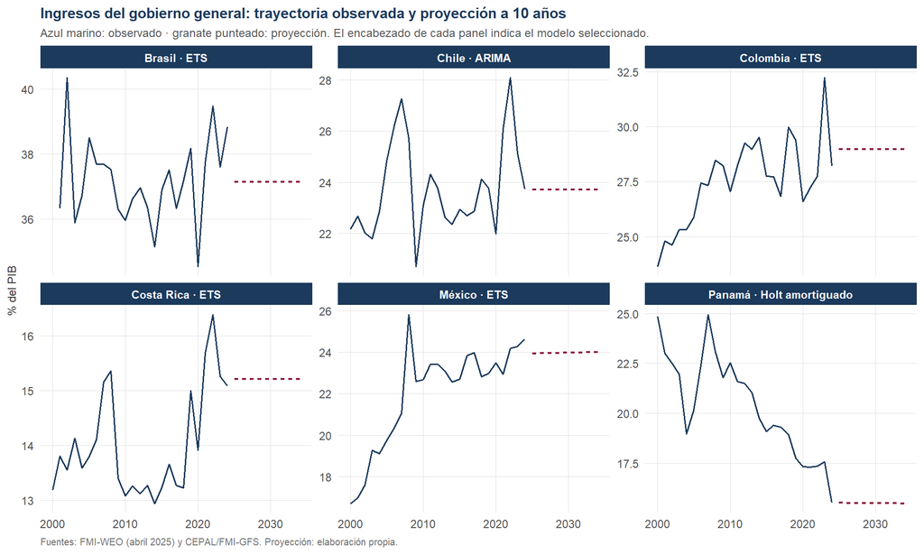

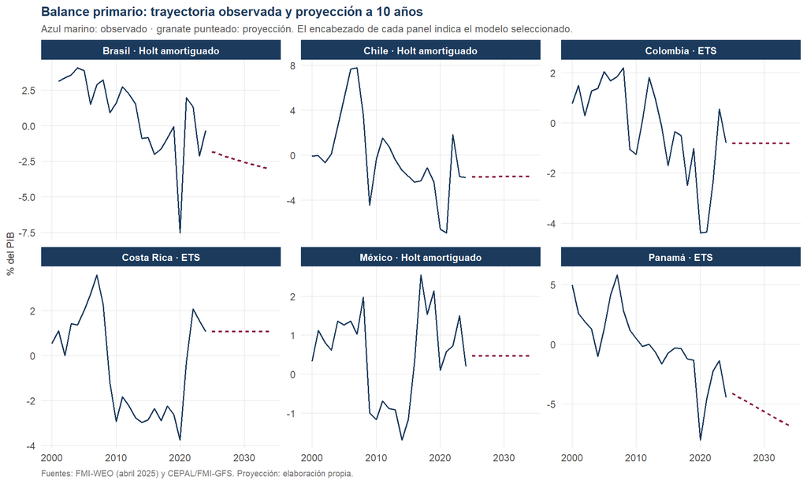

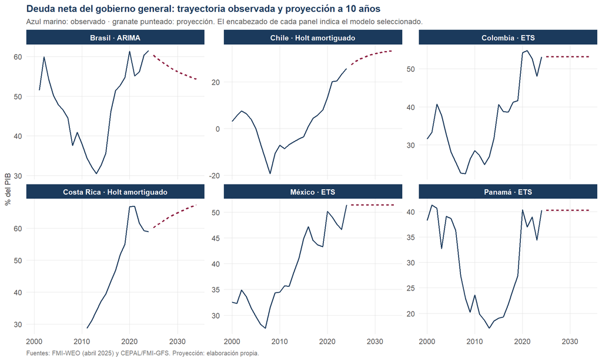

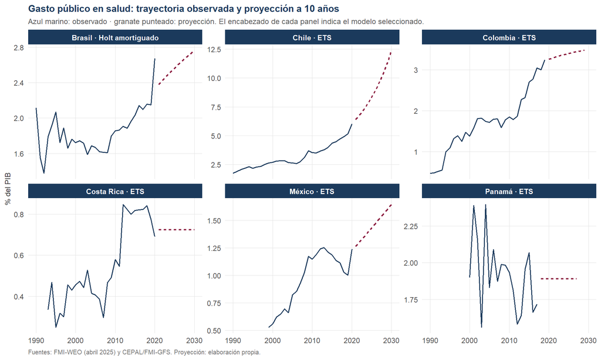

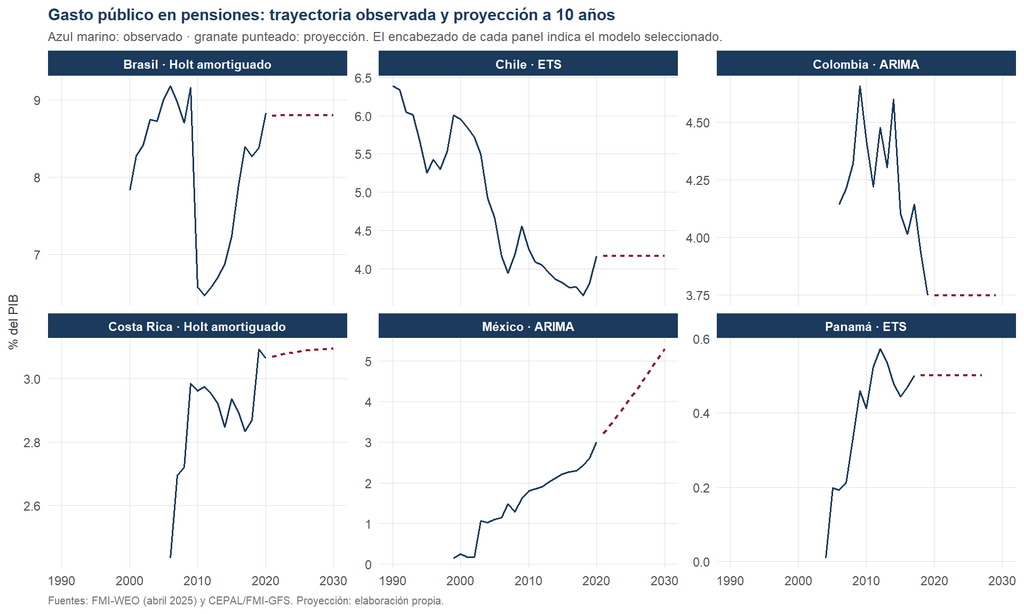

```r
archivos_proj <- c(
  "Ingresos del gobierno general"   = "fig_proj_ingresos",
  "Balance primario"                = "fig_proj_balance",
  "Deuda neta del gobierno general" = "fig_proj_deuda",
  "Gasto público en salud"          = "fig_proj_salud",
  "Gasto público en pensiones"      = "fig_proj_pensiones"
)

for (ind in levels(df_fiscal$indicador)) {
  fc_i <- fc_tidy %>% filter(indicador == ind)
  if (!nrow(fc_i)) next

  panel_lab <- fc_i %>% distinct(pais, modelo) %>%
    mutate(panel = paste0(pais, " · ", modelo))

  fc_i   <- left_join(fc_i, panel_lab, by = c("pais", "modelo"))
  hist_i <- df_fiscal %>% filter(indicador == ind) %>%
    inner_join(panel_lab, by = "pais")

  g <- ggplot() +
    geom_line(data = hist_i, aes(anio, valor), color = color_hist, linewidth = 0.7) +
    geom_line(data = fc_i, aes(anio, media), color = color_fc,
              linetype = "22", linewidth = 0.8) +
    facet_wrap(~ panel, scales = "free_y", nrow = 2) +
    labs(title = paste0(ind, ": trayectoria observada y proyección a ", h_final, " años"),
         subtitle = "Azul marino: observado · granate punteado: proyección. El encabezado de cada panel indica el modelo seleccionado.",
         x = NULL, y = "% del PIB",
         caption = "Fuentes: FMI-WEO (abril 2025) y CEPAL/FMI-GFS. Proyección: elaboración propia.") +
    theme_caf()

  print(g)
  ggsave(paste0("graficas/", archivos_proj[[ind]], ".png"), g,
         width = 10, height = 6, dpi = 300)
}
```

# 4 Base de datos consolidada

Se construye una base única en formato largo con todas las observaciones y proyecciones utilizadas en el documento, con trazabilidad completa de origen, naturaleza del dato y especificación empleada.

```r
# --- Códigos ISO3 ---
iso3_map <- c("Brasil" = "BRA", "Chile" = "CHL", "Colombia" = "COL",
              "Costa Rica" = "CRI", "México" = "MEX", "Panamá" = "PAN")

# --- Último año observado según el FMI (columna "Estimates Start After") ---
# A partir de ese año los valores del WEO son estimación, no dato observado.
estim_desde <- weo_raw %>%
  filter(!is.na(ISO)) %>%
  distinct(ISO, `Estimates Start After`) %>%
  transmute(pais = recode(ISO, BRA = "Brasil", CHL = "Chile", COL = "Colombia",
                          CRI = "Costa Rica", MEX = "México", PAN = "Panamá"),
            ultimo_observado = as.integer(`Estimates Start After`))

knitr::kable(estim_desde,
             caption = "Último año observado por país en el WEO; los posteriores son estimación del FMI")
```

Último año observado por país en el WEO; los posteriores son estimación del FMI

| pais | ultimo_observado |
| --- | --- |
| Brasil | 2023 |
| Chile | 2024 |
| Colombia | 2024 |
| Costa Rica | 2023 |
| México | 2024 |
| Panamá | 2023 |

```r
# --- Metadatos por indicador ---
meta_ind <- tibble::tribble(
  ~indicador,                          ~codigo,        ~unidad,        ~cobertura,          ~fuente,
  "Ingresos del gobierno general",     "GGR_NGDP",     "% del PIB",    "Gobierno general",  "FMI, World Economic Outlook, abril 2025",
  "Balance primario",                  "GGXONLB_NGDP", "% del PIB",    "Gobierno general",  "FMI, World Economic Outlook, abril 2025",
  "Deuda neta del gobierno general",   "GGXWDN_NGDP",  "% del PIB",    "Gobierno general",  "FMI, World Economic Outlook, abril 2025",
  "Gasto público en salud",            "GFS_SALUD",    "% del PIB",    "Gobierno central",  "CEPAL/FMI-GFS, gasto público por función",
  "Gasto público en pensiones",        "GFS_PENSIONES","% del PIB",    "Gobierno central",  "CEPAL/FMI-GFS, gasto público por función"
)

# --- Nota de construcción de la serie de pensiones, por país ---
nota_pensiones <- regla_pensiones %>%
  transmute(pais,
            nota_pen = if_else(incluye_enf,
              "Suma de edad avanzada y enfermedad e incapacidad",
              "Sólo edad avanzada; cota inferior del gasto en pensiones"))
```

```r
# --- Bloque 1: fiscal observado / estimado ---
base_fiscal_obs <- df_fiscal %>%
  left_join(estim_desde, by = "pais") %>%
  mutate(
    tipo = if_else(anio > ultimo_observado & indicador %in%
                     c("Ingresos del gobierno general", "Balance primario",
                       "Deuda neta del gobierno general"),
                   "Estimación de la fuente", "Observado"),
    modelo = NA_character_
  ) %>%
  select(pais, anio, indicador, tipo, modelo, valor)

# --- Bloque 2: fiscal proyectado (modelos propios) ---
base_fiscal_fc <- fc_tidy %>%
  transmute(pais, anio, indicador, tipo = "Proyección propia",
            modelo, valor = media)

# --- Bloque 3: demografía (UN WPP: estimación hasta 2023, proyección después) ---
base_demog <- df_demog %>%
  mutate(tipo = if_else(periodo == "Estimación", "Observado", "Proyección de la fuente"),
         modelo = NA_character_) %>%
  select(pais, anio, indicador, tipo, modelo, valor)

meta_demog <- tibble::tribble(
  ~indicador,                                    ~codigo,     ~unidad,            ~cobertura, ~fuente,
  "Tasa global de fecundidad (hijos por mujer)", "WPP_TFR",   "hijos por mujer",  "Nacional", "UN World Population Prospects 2024, revisión mediana",
  "Razón de dependencia senil (%)",              "WPP_RDSEN", "%",                "Nacional", "UN World Population Prospects 2024, revisión mediana"
)

# --- Consolidación ---
base_analisis <- bind_rows(base_fiscal_obs, base_fiscal_fc, base_demog) %>%
  mutate(indicador = as.character(indicador)) %>%
  left_join(bind_rows(meta_ind, meta_demog), by = "indicador") %>%
  left_join(nota_pensiones, by = "pais") %>%
  mutate(
    iso3 = unname(iso3_map[pais]),
    # Nota compuesta: regla de construcción (pensiones) y/o advertencia de
    # cobertura institucional (países con seguridad social fuera del gob. central)
    nota_cobertura = if_else(
      indicador %in% c("Gasto público en salud", "Gasto público en pensiones") &
        pais %in% c("Costa Rica", "Panamá", "México"),
      "Excluye seguridad social autónoma; subestima el gasto efectivo",
      NA_character_),
    nota_construccion = if_else(indicador == "Gasto público en pensiones",
                                nota_pen, NA_character_),
    nota = case_when(
      !is.na(nota_construccion) & !is.na(nota_cobertura) ~
        paste(nota_construccion, nota_cobertura, sep = ". "),
      !is.na(nota_construccion) ~ nota_construccion,
      !is.na(nota_cobertura)    ~ nota_cobertura,
      TRUE ~ NA_character_
    ),
    valor = round(valor, 4)
  ) %>%
  transmute(
    pais, iso3, anio,
    indicador, codigo_indicador = codigo,
    tipo, modelo,
    valor, unidad,
    cobertura_institucional = cobertura,
    fuente, nota
  ) %>%
  arrange(indicador, pais, anio)

# --- Validaciones ---
stopifnot(
  !any(is.na(base_analisis$valor)),
  !any(is.na(base_analisis$iso3)),
  !any(is.na(base_analisis$codigo_indicador)),
  !any(duplicated(base_analisis[, c("pais", "anio", "indicador")]))
)

# Se escribe con readr::write_excel_csv, que genera UTF-8 CON BOM.
# El BOM es lo que permite a Excel en Windows reconocer la codificación;
# write.csv(fileEncoding = "UTF-8") no lo incluye y produce mojibake
# ("MÃ©xico" en lugar de "México") al abrir el archivo desde Excel.
readr::write_excel_csv(base_analisis, "base_analisis_P3.csv")

cat("base_analisis_P3.csv —", nrow(base_analisis), "filas,",
    ncol(base_analisis), "columnas\n\n")
```

```
## base_analisis_P3.csv — 1745 filas, 12 columnas
```

```r
count(base_analisis, indicador, tipo) %>% knitr::kable(caption = "Composición de la base")
```

Composición de la base

| indicador | tipo | n |
| --- | --- | --- |
| Balance primario | Estimación de la fuente | 3 |
| Balance primario | Observado | 146 |
| Balance primario | Proyección propia | 60 |
| Deuda neta del gobierno general | Estimación de la fuente | 3 |
| Deuda neta del gobierno general | Observado | 135 |
| Deuda neta del gobierno general | Proyección propia | 60 |
| Gasto público en pensiones | Observado | 117 |
| Gasto público en pensiones | Proyección propia | 60 |
| Gasto público en salud | Observado | 160 |
| Gasto público en salud | Proyección propia | 60 |
| Ingresos del gobierno general | Estimación de la fuente | 3 |
| Ingresos del gobierno general | Observado | 146 |
| Ingresos del gobierno general | Proyección propia | 60 |
| Razón de dependencia senil (%) | Observado | 204 |
| Razón de dependencia senil (%) | Proyección de la fuente | 162 |
| Tasa global de fecundidad (hijos por mujer) | Observado | 204 |
| Tasa global de fecundidad (hijos por mujer) | Proyección de la fuente | 162 |

```r
diccionario <- tibble::tribble(
  ~Campo,                     ~Descripción,
  "pais",                     "Nombre del país",
  "iso3",                     "Código ISO 3166-1 alfa-3",
  "anio",                     "Año de referencia",
  "indicador",                "Nombre del indicador",
  "codigo_indicador",         "Código de la serie en la fuente original",
  "tipo",                     "Observado | Estimación de la fuente | Proyección de la fuente | Proyección propia",
  "modelo",                   "Especificación empleada; vacío salvo en proyección propia",
  "valor",                    "Valor del indicador",
  "unidad",                   "Unidad de medida",
  "cobertura_institucional",  "Perímetro institucional del dato",
  "fuente",                   "Fuente primaria",
  "nota",                     "Advertencia de construcción o comparabilidad, cuando aplica"
)

# --- Advertencia de uso sobre las proyecciones de gasto funcional ---
nota_uso <- tibble::tribble(
  ~Campo, ~Descripción,
  "ADVERTENCIA DE USO",
  paste(
    "Las proyecciones de gasto en salud y pensiones (tipo = 'Proyección propia')",
    "parten de un último dato observado en 2020 en cuatro de los seis países, año",
    "afectado por el choque sanitario. Dado que la ventana de validación del modelo",
    "(últimos cuatro años) contiene dicho choque, la selección favorece",
    "especificaciones de tendencia no amortiguada que extrapolan el incremento de",
    "2020 como si fuera estructural. Esto es particularmente relevante en tres",
    "series: gasto en salud de Chile (6.03 en 2020 a 12.38 en 2030), gasto en",
    "pensiones de México (3.01 a 5.30) y gasto en salud de México (1.24 a 1.65),",
    "cuyas trayectorias exceden el rango histórico observado. Estas proyecciones",
    "deben interpretarse como cota superior de un escenario inercial, no como",
    "estimación central. Los agregados fiscales del WEO no presentan esta",
    "limitación por disponer de datos hasta 2024."
  )
)

diccionario <- bind_rows(diccionario, nota_uso)

knitr::kable(diccionario, caption = "Diccionario de variables")
```

Diccionario de variables

| Campo | Descripción |
| --- | --- |
| pais | Nombre del país |
| iso3 | Código ISO 3166-1 alfa-3 |
| anio | Año de referencia |
| indicador | Nombre del indicador |
| codigo_indicador | Código de la serie en la fuente original |
| tipo | Observado \| Estimación de la fuente \| Proyección de la fuente \| Proyección propia |
| modelo | Especificación empleada; vacío salvo en proyección propia |
| valor | Valor del indicador |
| unidad | Unidad de medida |
| cobertura_institucional | Perímetro institucional del dato |
| fuente | Fuente primaria |
| nota | Advertencia de construcción o comparabilidad, cuando aplica |
| ADVERTENCIA DE USO | Las proyecciones de gasto en salud y pensiones (tipo = ‘Proyección propia’) parten de un último dato observado en 2020 en cuatro de los seis países, año afectado por el choque sanitario. Dado que la v… |

```r
exportar_tex(diccionario, "anexo_diccionario_base.tex", alinear = c("l", "l"))

readr::write_excel_csv(diccionario, "base_analisis_P3_diccionario.csv")
```

```r
# Control automático: detecta proyecciones que exceden el rango histórico
# observado en más de medio rango. Reproduce la revisión que originó la
# advertencia de uso; si al reejecutar aparecen series nuevas, deben añadirse
# a esa nota o corregirse la especificación.
control_rango <- base_analisis %>%
  filter(tipo != "Proyección de la fuente") %>%
  group_by(indicador, pais) %>%
  summarise(
    hist_min  = min(valor[tipo != "Proyección propia"]),
    hist_max  = max(valor[tipo != "Proyección propia"]),
    ultimo    = valor[tipo != "Proyección propia"][which.max(anio[tipo != "Proyección propia"])],
    fin_proy  = if (any(tipo == "Proyección propia"))
                  valor[tipo == "Proyección propia"][which.max(anio[tipo == "Proyección propia"])]
                else NA_real_,
    modelo    = first(na.omit(modelo)),
    .groups = "drop"
  ) %>%
  filter(!is.na(fin_proy)) %>%
  mutate(
    rango  = hist_max - hist_min,
    excede = fin_proy > hist_max + 0.5 * rango | fin_proy < hist_min - 0.5 * rango
  )

alertas <- filter(control_rango, excede)

if (nrow(alertas)) {
  warning("Proyecciones fuera del rango histórico: ", nrow(alertas), " serie(s).")
  alertas %>%
    transmute(Indicador = indicador, País = pais, Modelo = modelo,
              `Hist. mín` = round(hist_min, 2), `Hist. máx` = round(hist_max, 2),
              `Último obs.` = round(ultimo, 2), `Fin proyección` = round(fin_proy, 2)) %>%
    knitr::kable(caption = "ALERTA: proyecciones que exceden el rango histórico observado")
} else {
  cat("Ninguna proyección excede el rango histórico observado.\n")
}
```

ALERTA: proyecciones que exceden el rango histórico observado

| Indicador | País | Modelo | Hist. mín | Hist. máx | Último obs. | Fin proyección |
| --- | --- | --- | --- | --- | --- | --- |
| Gasto público en pensiones | México | ARIMA | 0.15 | 3.01 | 3.01 | 5.30 |
| Gasto público en salud | Chile | ETS | 1.75 | 6.03 | 6.03 | 12.38 |
| Gasto público en salud | México | ETS | 0.53 | 1.25 | 1.24 | 1.65 |

```r
cat("Salidas generadas:\n",
    "  graficas/                     figuras del documento y del anexo\n",
    "  tablas/                       fragmentos LaTeX\n",
    "  base_analisis_P3.csv          base consolidada\n",
    "  base_analisis_P3_diccionario.csv  diccionario de variables\n")
```

```
## Salidas generadas:
##    graficas/                     figuras del documento y del anexo
##    tablas/                       fragmentos LaTeX
##    base_analisis_P3.csv          base consolidada
##    base_analisis_P3_diccionario.csv  diccionario de variables
```

# 5 Anexo técnico: quiebres estructurales

> **Nota de alcance.** Este material **no forma parte del texto del Producto 3** por decisión de diseño del documento: los quiebres se detectan pero no se modelan dentro de las especificaciones ARIMA/ETS/Holt, y su inclusión desviaría la narrativa descriptiva hacia el diagnóstico econométrico. Se conserva aquí completo, con figuras y tabla exportadas, como respaldo de auditoría y como insumo para el Producto 4.

**Marco.** El estadístico F de Chow evalúa, en cada punto candidato de la muestra, si partirla en ese punto mejora significativamente el ajuste. Su versión formal —el test supF de Quandt-Andrews, implementado en `sctest()`— toma el máximo de esa secuencia y lo contrasta contra una distribución no estándar, bajo H$_0$: los parámetros son constantes en toda la muestra. El procedimiento de Bai-Perron (`breakpoints()`) va más allá: identifica simultáneamente el número y la ubicación óptimos de múltiples quiebres, minimizando la suma de residuales al cuadrado sobre todas las particiones admisibles y seleccionando el número de quiebres por BIC. Requiere un tamaño mínimo de segmento (15 % de la muestra por defecto), por lo que sólo se aplica a series con al menos 20 observaciones.

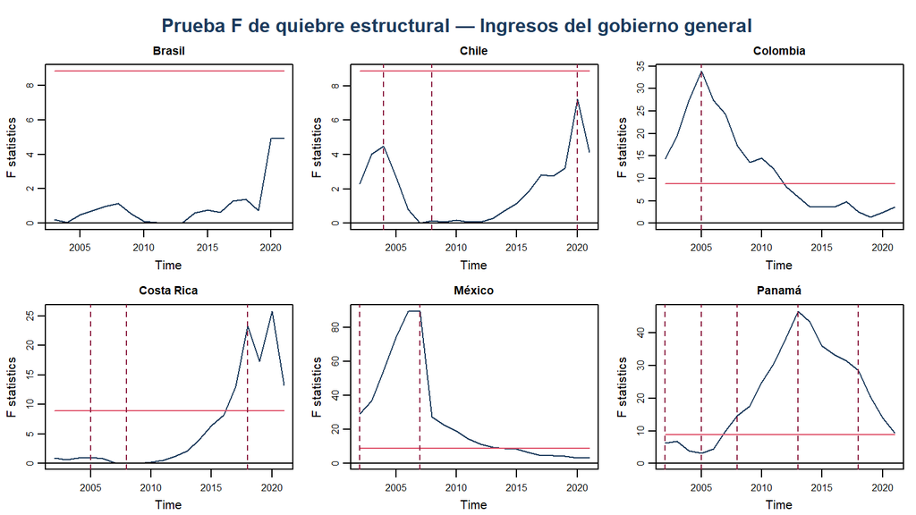

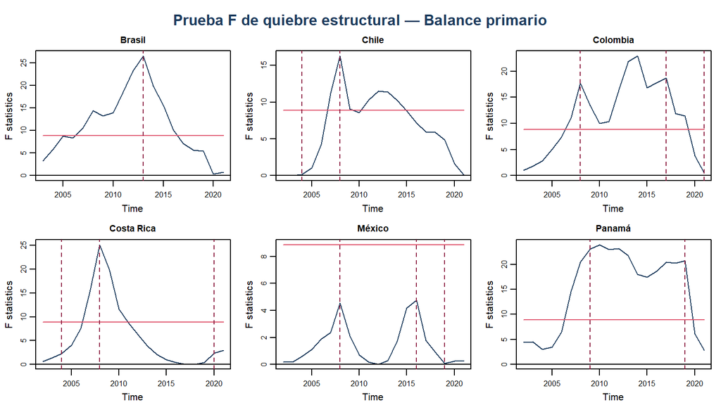

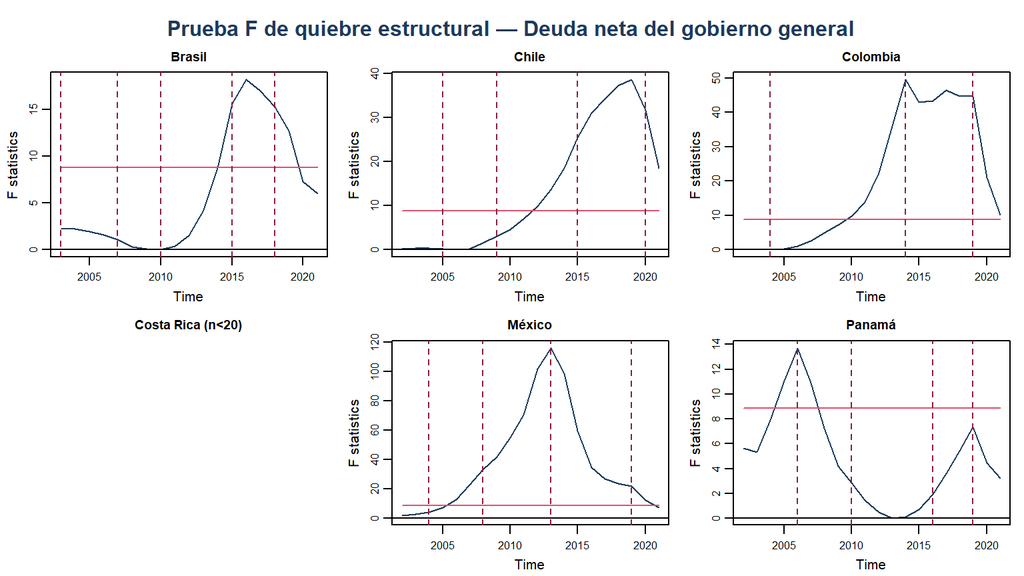

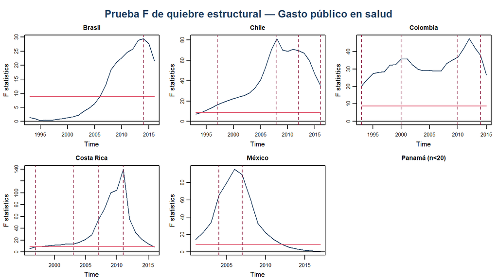

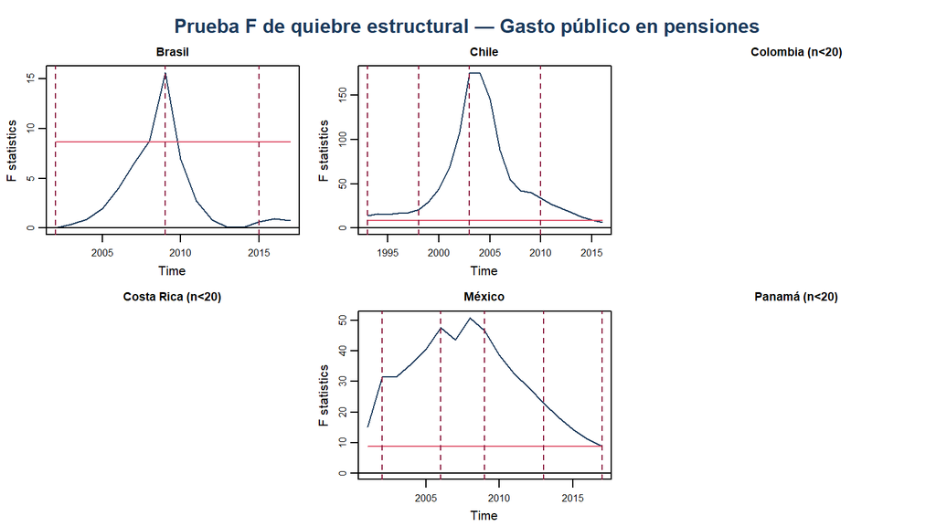

```r
grid_quiebres <- function(ind) {
  idx <- which(claves$indicador == ind)
  par(mfrow = c(2, 3), oma = c(0, 0, 2.3, 0), mar = c(3, 3, 2, 0.8),
      mgp = c(1.8, 0.6, 0), cex.axis = 0.75)
  for (i in idx) {
    y <- series_list[[i]]
    if (length(y) < 20) {
      plot.new(); title(main = paste0(claves$pais[i], " (n<20)"), cex.main = 0.9)
      next
    }
    fs <- tryCatch(Fstats(y ~ 1), error = function(e) NULL)
    if (is.null(fs)) { plot.new(); title(main = paste0(claves$pais[i], " (s/d)")); next }
    plot(fs, main = claves$pais[i], cex.main = 0.9, col = "#1B3A5C")
    bp <- tryCatch(breakpoints(y ~ 1), error = function(e) NULL)
    fechas <- if (!is.null(bp)) breakdates(bp) else NA
    if (!all(is.na(fechas))) abline(v = fechas, col = "#8C1D40", lty = 2, lwd = 1.3)
  }
  mtext(paste0("Prueba F de quiebre estructural — ", ind),
        outer = TRUE, cex = 1, font = 2, col = "#1B3A5C")
  par(mfrow = c(1, 1))
}

slug <- function(x) gsub("(^_|_$)", "", gsub("[^a-z0-9]+", "_",
       tolower(iconv(x, from = "", to = "ASCII//TRANSLIT"))))

for (ind in levels(df_fiscal$indicador)) {
  grid_quiebres(ind)
  png(paste0("graficas/anexo_quiebres_", slug(ind), ".png"),
      width = 8, height = 4.5, units = "in", res = 300)
  grid_quiebres(ind); dev.off()
}
```

**Lectura de las figuras.** El encabezado superior identifica el indicador; cada recuadro corresponde a un país. La línea azul marino traza el estadístico F a lo largo de los puntos candidatos: picos pronunciados señalan momentos en que partir la muestra mejora sustancialmente el ajuste. Las líneas punteadas granate marcan las fechas de quiebre seleccionadas por Bai-Perron.

```r
tab_quiebres <- map_dfr(seq_len(nrow(claves)), function(i) {
  y <- series_list[[i]]
  base <- tibble(Indicador = as.character(claves$indicador[i]),
                 País = claves$pais[i], n = length(y))

  if (length(y) < 20) {
    return(mutate(base, `supF (p)` = NA_real_, Quiebres = "n < 20 (no evaluado)"))
  }

  fs <- tryCatch(Fstats(y ~ 1), error = function(e) NULL)
  p_f <- if (!is.null(fs)) tryCatch(sctest(fs)$p.value, error = function(e) NA_real_) else NA_real_
  bp  <- tryCatch(breakpoints(y ~ 1), error = function(e) NULL)
  fechas <- if (!is.null(bp)) breakdates(bp) else NA

  mutate(base,
         `supF (p)` = round(p_f, 3),
         Quiebres = if (all(is.na(fechas))) "Sin quiebres"
                    else paste(round(fechas, 0), collapse = ", "))
})

knitr::kable(tab_quiebres,
             caption = "Prueba supF de constancia de parámetros y fechas de quiebre (Bai-Perron, criterio BIC)")
```

Prueba supF de constancia de parámetros y fechas de quiebre (Bai-Perron, criterio BIC)

| Indicador | País | n | supF (p) | Quiebres |
| --- | --- | --- | --- | --- |
| Ingresos del gobierno general | Brasil | 24 | 0.279 | Sin quiebres |
| Ingresos del gobierno general | Chile | 25 | 0.104 | 2004, 2008, 2020 |
| Ingresos del gobierno general | Colombia | 25 | 0.000 | 2005 |
| Ingresos del gobierno general | Costa Rica | 25 | 0.000 | 2005, 2008, 2018 |
| Ingresos del gobierno general | México | 25 | 0.000 | 2002, 2007 |
| Ingresos del gobierno general | Panamá | 25 | 0.000 | 2002, 2005, 2008, 2013, 2018 |
| Balance primario | Brasil | 24 | 0.000 | 2013 |
| Balance primario | Chile | 25 | 0.001 | 2004, 2008 |
| Balance primario | Colombia | 25 | 0.000 | 2008, 2017, 2021 |
| Balance primario | Costa Rica | 25 | 0.000 | 2004, 2008, 2020 |
| Balance primario | México | 25 | 0.304 | 2008, 2016, 2019 |
| Balance primario | Panamá | 25 | 0.000 | 2009, 2019 |
| Deuda neta del gobierno general | Brasil | 24 | 0.001 | 2003, 2007, 2010, 2015, 2018 |
| Deuda neta del gobierno general | Chile | 25 | 0.000 | 2005, 2009, 2015, 2020 |
| Deuda neta del gobierno general | Colombia | 25 | 0.000 | 2004, 2014, 2019 |
| Deuda neta del gobierno general | Costa Rica | 14 | NA | n < 20 (no evaluado) |
| Deuda neta del gobierno general | México | 25 | 0.000 | 2004, 2008, 2013, 2019 |
| Deuda neta del gobierno general | Panamá | 25 | 0.005 | 2006, 2010, 2016, 2019 |
| Gasto público en salud | Brasil | 31 | 0.000 | 2014 |
| Gasto público en salud | Chile | 31 | 0.000 | 1997, 2008, 2012, 2016 |
| Gasto público en salud | Colombia | 30 | 0.000 | 1993, 2000, 2010, 2014 |
| Gasto público en salud | Costa Rica | 28 | 0.000 | 1997, 2003, 2007, 2011 |
| Gasto público en salud | México | 22 | 0.000 | 2004, 2007 |
| Gasto público en salud | Panamá | 18 | NA | n < 20 (no evaluado) |
| Gasto público en pensiones | Brasil | 21 | 0.002 | 2002, 2009, 2015 |
| Gasto público en pensiones | Chile | 31 | 0.000 | 1993, 1998, 2003, 2010 |
| Gasto público en pensiones | Colombia | 14 | NA | n < 20 (no evaluado) |
| Gasto público en pensiones | Costa Rica | 15 | NA | n < 20 (no evaluado) |
| Gasto público en pensiones | México | 22 | 0.000 | 2002, 2006, 2009, 2013, 2017 |
| Gasto público en pensiones | Panamá | 14 | NA | n < 20 (no evaluado) |

```r
exportar_tex(tab_quiebres, "anexo_tab_quiebres.tex")
```

**Interpretación.** Un valor $p$ inferior a 0.05 rechaza la constancia de parámetros: hay evidencia de al menos un cambio en el proceso generador. Los quiebres en torno a 2020 corresponden al choque sanitario; los anteriores suelen coincidir con reformas tributarias o con el ciclo de precios de materias primas.

La consecuencia metodológica es directa y conviene dejarla asentada: ARIMA, ETS y Holt asumen parámetros constantes. Un quiebre no modelado implica que la estimación promedia dos regímenes distintos, lo que sesga la proyección hacia el comportamiento del régimen más largo. Con series de entre 14 y 31 observaciones anuales, partir la muestra en submuestras por régimen dejaría un número de grados de libertad insuficiente para estimar cualquiera de las tres familias. La decisión adoptada —detectar, documentar y declarar la limitación en lugar de corregir con una muestra insuficiente— es la defendible dado el tamaño muestral disponible.

```r
tab_quiebres %>%
  filter(!is.na(`supF (p)`)) %>%
  summarise(
    series_evaluadas   = n(),
    rechaza_constancia = sum(`supF (p)` < 0.05),
    con_quiebre_BP     = sum(Quiebres != "Sin quiebres")
  )
```

| series_evaluadas | rechaza_constancia | con_quiebre_BP |
| --- | --- | --- |
| 25 | 22 | 24 |

```r
# Cifras citadas en el texto LaTeX (verificación al recompilar)
list(
  series_evaluadas   = nrow(resultados),
  modelo_predominante = frecuencia_modelos$Modelo[1],
  n_predominante     = frecuencia_modelos$`Series ganadas`[1],
  ljung_ok           = sum(resultados$LjungBox > 0.05, na.rm = TRUE),
  ljung_evaluables   = sum(!is.na(resultados$LjungBox)),
  mase_menor_1       = sum(resultados$MASE < 1, na.rm = TRUE)
)
```

```
## $series_evaluadas
## [1] 30
##
## $modelo_predominante
## [1] "ETS"
##
## $n_predominante
## [1] 17
##
## $ljung_ok
## [1] 30
##
## $ljung_evaluables
## [1] 30
##
## $mase_menor_1
## [1] 12
```